# Narrative_ AKA_MY_TG

## Section 1

### Section 1.1

********* A/ Generate the data from original replication file *********

- Download and save the different datasets included in the replication folder from https://www.journals.uchicago.edu/doi/suppl/10.1086/720458/suppl_file/20190733data.zip
- We will use the NTL data DMSP-OLS, as well as the Freedom In the World Indicator data from Freedom House and the World Bank Development Indicators
- Open the “setup.do” file in Stata. Adjust the global “dir” in line 40, and run.
- Data preparation:

```
*Keep only the variables we need

use "${dir}\Data\master\Estimations", clear

keep gdp14_growth dn13_growth year countrycode lngdp14 lndn13 lndn13_fiw fiw autocracyFH Dpfree Dnfree fiw_unadj \
\
\
```

******* Set the globals and the dir. Prepare the data *******

```
clear all
set more off
global dir "XXX"

global tables "${dir}\Output\Tables"
global figures "${dir}\Output\Figures"
global temp "${dir}\Data\temp"
global sigmas "${dir}\Data\temp\sigmas"


cd "XXX"

use ZAM_sample_in.dta, clear

gen ctryf = countrycode
encode ctryf, gen(ctry_f)
gen year_f = year

regress lngdp14 lndn13 fiw fiw2 lndn13_fiw i.ctry_f i.year_f, vce(robust)

estimates store reg_model
outreg2 using regression_results.doc, replace word // Requires `outreg2` package for exporting.


regress lngdp14 lndn13 fiw fiw2 lndn13_fiw i.ctry_f i.year

predict cooksd, cooksd    // Cook's Distance
predict dfits, dfits      // DFITS

gen threshold_cooksd = 4 / e(N) // Common threshold for Cook's Distance
gen out_zam_sign = (cooksd > threshold_cooksd)

gen threshold_dfits = 2 * sqrt(e(k) / e(N)) // DFITS threshold
gen out_zam_sig = (abs(dfits) > threshold_dfits)

gen out_zam_both = (out_zam_sign == 1 & out_zam_sig == 1)

regress lngdp14 lndn13 fiw fiw2 lndn13_fiw i.ctry_f i.year, vce(robust)

save ZAM_sample_out.dta, replace




global seed 20051702    //seed used for bootstrap in estimation of sigma SE
global reps=1000    //number of repetitions for bootstrap

local i=1   // this local identifies each estimate of sigma

timer clear 1
timer on 1
```

### Section 1.2

## Section 2: Output 1

Figure 1: Average growth rate: NTL and GDP Figure shows separate binned scatter plots of yearly growth in real GDP(constant local currency) and NTLforcountry-years classified as democracies and autocracies. Classification based on the binary measure of electoral democracy produced by Freedom House. Figure also shows separate lines of best fit, which are estimated using the disaggregate data without binning. Sample size: 3,432. Sample period: 1993–2013.  
This first output is the only figure included in the “Summary Statistics” section of the article. We observe a positive relationship between growth rate of NTL and GDP for the two types of political regimes: autocracy and democracy. But the reported GDP growth is, on average, more important for autocracy, for a given NTL growth.

- Code for the Figure 1:

[output not shown]

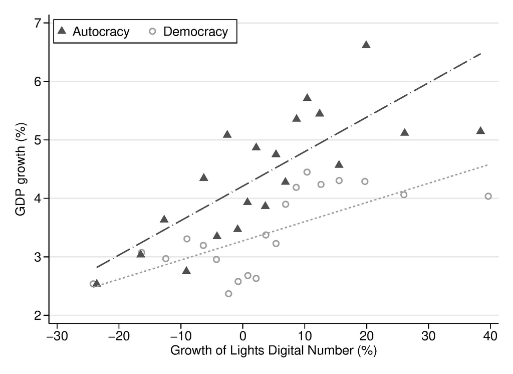